# 3 Calibration Methods – Optimization Algorithms

Stefan Scholz

2022-09-14

### Background

The outbreak investigation of the first 50 days is completed and all fax messages with reported cases finally arrived at your research institute. After talking to the field team, they are fairly confident about all the gathered data on the outbreak, besides the secondary attack rate (SAR). You are given the data set to use your model to check if the secondary attack rate seems plausible.

### Mandatory Tasks

Take your model from exercise 2 and try to calibrate your model to the number of cases, given the data from the outbreak and using the secondary attack rate (beta) as a free parameter.

- Read in the dataset ‘’observed_cases.csv’’
- Try to plot the model results against the observed values by extending the *plot.ode* function

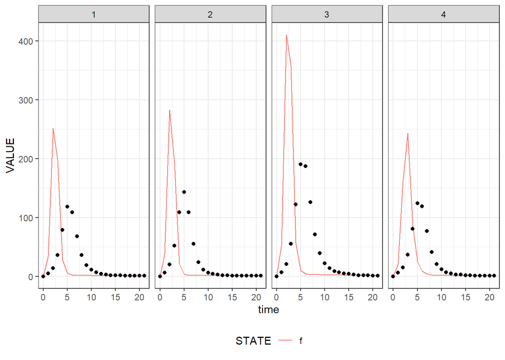

```r
obs <- read.csv("../1_input/observed_cases.csv")

plot.ode <- function(model, obs) {
  model <- model %>% filter(STATE == "f") %>%
    group_by(AGE) %>% mutate(VALUE = VALUE - lag(VALUE, default = 0))
  obs <- obs %>% rename(time = DAY, VALUE = CASES) %>% mutate(VALUE = round(VALUE, 0))
  p <- ggplot()
  p <- p + geom_line(data = model, aes(x=time, y = VALUE, color=STATE))
  p <- p + geom_point(data = obs, aes(x=time, y = VALUE))
  p <- p + facet_grid(.~AGE)
  p <- p + theme_bw() + theme(legend.position = "bottom")
  p
}

inits <- c(S = c(516, 537, 888, 548), I = c(2, 1, 3, 4), R = c(0, 0, 0, 0), flow.I = c(0, 0, 0, 0))
times <- 0:21
contacts <- read.csv("../1_input/social_contact_matrix.csv")
parms <- list(gamma = c(1/2, 1/3, 1/3, 1/5),
              sigma = 1/180,
              beta = 0.4,
              contacts = as.matrix(contacts))

res.sirs <- run.ode(times = times, inits = inits, parms = parms, ode.func = sirs)
plot.ode(res.sirs, obs)
```

- Create a new function *ode.fit* by extending the *run.ode* function, that
  - uses the observed incident cases and the model output to calculate and return a log-likelihood function (using an appropriate probability distribution)
  - allows for free parameters to be passed to the function as the first argument

```r
ode.fit <- function(parms.free, times, inits, parms.fix, ode.func, obs) {

  obs <- obs %>% rename(time = DAY) %>% mutate(AGE = as.character(AGE))

  parms <- c("beta" = parms.free, parms.fix)

  out.ode <- lsoda(y = inits, times = times, func = ode.func, parms = parms) %>%
    as.data.frame() %>% pivot_longer(names_to = "STATE", values_to = "VALUE", !1) %>%
    mutate(AGE = str_extract(STATE, "[:digit:]"), STATE = str_extract(STATE, "[:alpha:]")) %>%
    filter(STATE == "f") %>%
    group_by(AGE) %>% mutate(VALUE = VALUE - lag(VALUE, default = 0)) %>% ungroup() %>%
    left_join(obs, by = c("time", "AGE")) %>%
    mutate(LOGLIKE = dpois(CASES, VALUE, log = T)) %>%
    summarise(LOGLIKE = sum(LOGLIKE)) %>% pull(LOGLIKE)
  return(-2*out.ode)
}

ode.fit(0.4, times, inits, parms, sirs, obs)
```

```
## [1] 11337.32
```

- Use the *optim* function to search for the best-fitting parameters for the data.
  - Try to find a proper link-function to restrict beta on the intervall (0,1)
  - Compare computation time and results for the methods *Nelder-Mead* and *BFGS*
  - Try different values for the *reltol* argument in the control argument list. What is different?

```r
calib.1 <- optim(par = 0.2, fn = ode.fit, method = "Nelder-Mead",
               times = times, inits = inits, parms.fix = within(parms, rm(beta)), ode.func = sirs, obs = obs)
print(calib.1$par)
```

```
## [1] 0.1840332
```

```r
calib.2 <- optim(par = 0.2, fn = ode.fit, method = "BFGS",
               times = times, inits = inits, parms.fix = within(parms, rm(beta)), ode.func = sirs, obs = obs)
print(calib.2$par)
```

```
## [1] 0.1840374
```

- Plot the observed values against the model results of the model using the best-fitting parameters from the optimization

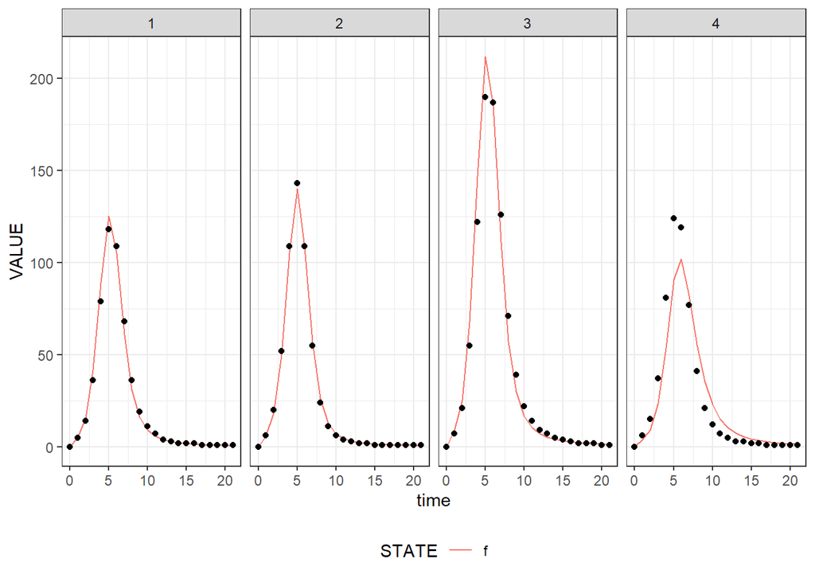

```r
inits <- c(S = c(516, 537, 888, 548), I = c(2, 1, 3, 4), R = c(0, 0, 0, 0), flow.I = c(0, 0, 0, 0))
times <- 0:21
contacts <- read.csv("../1_input/social_contact_matrix.csv")
parms <- list(gamma = c(1/2, 1/3, 1/3, 1/5),
              sigma = 1/180,
              beta = calib.1$par,
              contacts = as.matrix(contacts))

res.sirs <- run.ode(times = times, inits = inits, parms = parms, ode.func = sirs)
plot.ode(res.sirs, obs)
```

### Advanced Exercises

#### Meta-Parameters

There is some evidence to assume that not only the period of infectiousness, but also the infectivity (i.e., infecting somebody) is age-specific.

- Try calibrating the model with age-specific parameters of beta.
- If there are many age-groups, the number of free parameters might get relatively high leading to long calibration times. Think of a way to use only two parameters to achieve age-specific values of beta for each age-group in your model

#### Optimization algorithms

Have a look at the following website on [CRAN](https://cran.r-project.org/web/views/Optimization.html) giving an overview on all available optimization libraries in R.

- Choose a package of your choice and try to implement another optimization function